# About

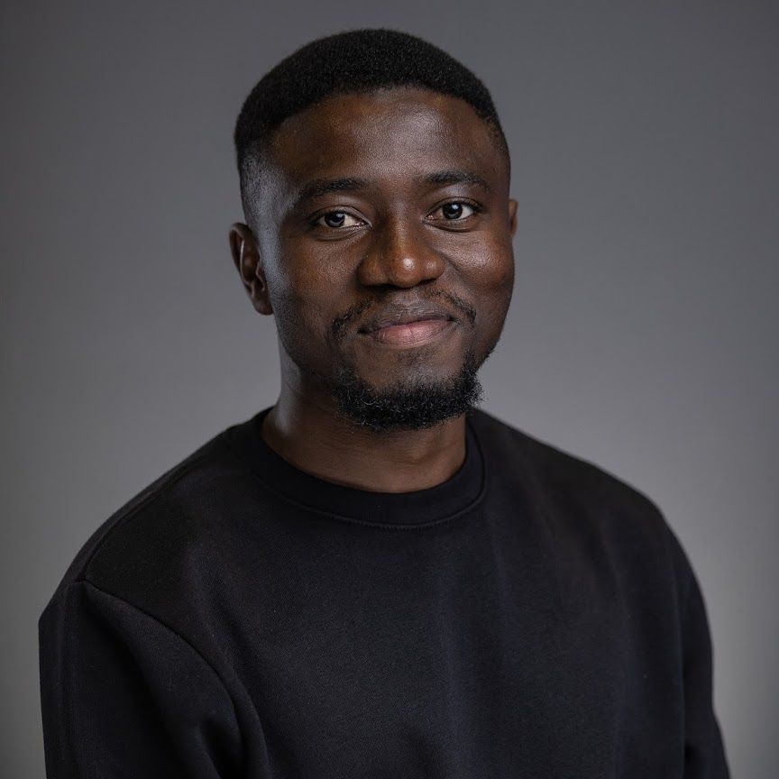

I believe that numbers tell stories — sometimes quietly, sometimes in ways that surprise us.  
I’m fascinated by how data can reveal patterns that help us understand people, systems, and possibilities.  
Most days, I’m working on problems that live at the edge of statistics, machine learning, and communication — figuring out how to make insights *feel human* again.

### Now

I’m currently a PhD student in Statistics, exploring how modern methods in optimization and experimental design can make real-world decisions smarter and more efficient.  
Along the way, I’m learning to translate complex statistical ideas into stories that inspire — whether that’s through writing, teaching, or building tools that help others see data differently.

### Previously

Before diving deep into research, I spent time studying the foundations of data science, learning how numbers shape narratives, and building small projects that blend analytics with creativity.  
That mix of art and analysis is something I still carry into everything I do.

### Elsewhere

You can find me online here: